# Course Project - Practical Machine Learning

Sanket Bambodkar

5 June 2019

## Overview

Using devices such as Jawbone Up, Nike FuelBand, and Fitbit it is now possible to collect a large amount of data about personal activity relatively inexpensively. These type of devices are part of the quantified self movement – a group of enthusiasts who take measurements about themselves regularly to improve their health, to find patterns in their behavior, or because they are tech geeks. One thing that people regularly do is quantify how much of a particular activity they do, but they rarely quantify how well they do it. In this project, your goal will be to use data from accelerometers on the belt, forearm, arm, and dumbell of 6 participants. They were asked to perform barbell lifts correctly and incorrectly in 5 different ways.

The goal of your project is to predict the manner in which they did the exercise. This is the “classe” variable in the training set.

## Required Libraries

```r
library(caret)
library(rpart)
library(randomForest)
library(gbm)
library(rattle)
```

## Loading and Cleaning the data

```r
train <- read.csv(url("https://d396qusza40orc.cloudfront.net/predmachlearn/pml-training.csv"),header=TRUE)
test <- read.csv(url("https://d396qusza40orc.cloudfront.net/predmachlearn/pml-testing.csv"),header=TRUE)
```

Let’s look at the summary of train and test data.

```r
dim(train)
```

```
## [1] 19622   160
```

```r
dim(test)
```

```
## [1]  20 160
```

Data has observations on 160 different variables

```r
str(train)
```

[output not shown]

[output cut: 86 more lines]

Many columns in the data have majority of the values as ‘NA’ or they are blank. We will remove these columns from our model design. Also first seven columns of the data willl not affect our model so we will be removing them.

```r
blank <- which(colSums(is.na(train)|train == "")>0.9*dim(train)[1])
train <- train[, - blank]
train <- train[, - (1:7)]
dim(train)
```

```
## [1] 19622    53
```

Now doing the same treatment for test data set

```r
test <- test[, - blank]
test <- test[, - (1:7)]
dim(test)
```

```
## [1] 20 53
```

Now the data has 53 variables, last variable ‘classe’ is the outcome for us and other variables will be our predictors.

## Data partition and Cross Validation

Now parting the train data in train1 and test1 data set

```r
set.seed(12)
select <- createDataPartition(train$classe, p=0.75, list=FALSE)
train1 <- train[select,]
test1 <- train[-select,]
```

Let’s look at the dimensions of newly formed train1 and test1 datasets.

```r
dim(train1)
```

```
## [1] 14718    53
```

```r
dim(test1)
```

```
## [1] 4904   53
```

Now, let’s set cross validation technique. we will be using 5 fold cross validation. 5 fold cross validation is chosen to avoid overfitting of the model.  
Using caret package for this.

```r
crossVal <- trainControl(method = "cv", number = 5)
```

## Model Design

Classification Tree Model:

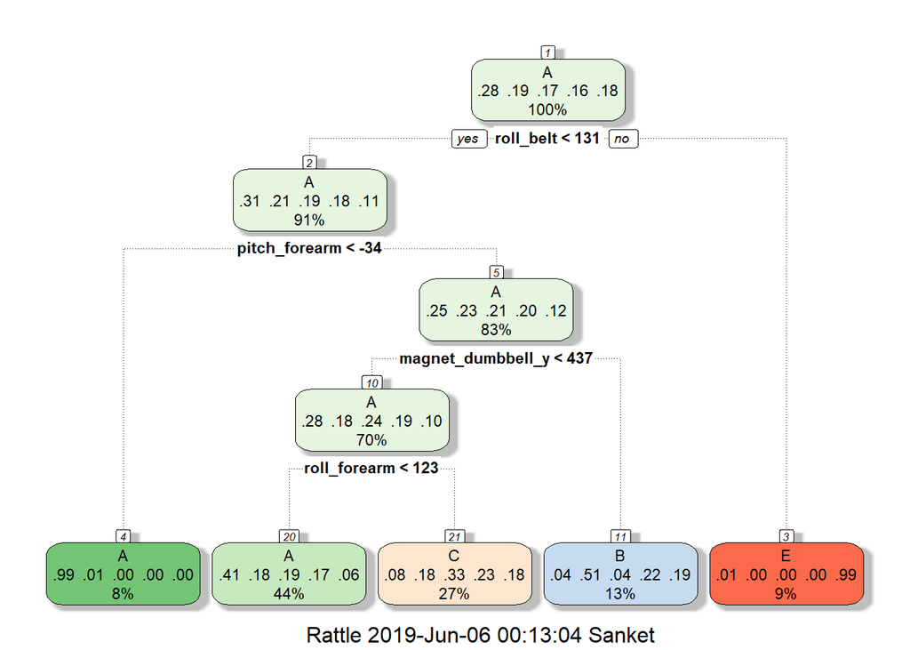

```r
model_rpart <- train(classe~., data=train1, method="rpart", trControl=crossVal)
fancyRpartPlot(model_rpart$finalModel)
```

Random Forest Model:

```r
model_rf <- train(classe~., data=train1, method="rf", trControl=crossVal)
```

Gradient Boosting Model:

```r
model_gbm <- train(classe~., data=train1, method="gbm", trControl=crossVal)
```

```r
model_lda <- train(classe~., data=train1, method="lda", trControl=crossVal)
```

## Model Selection

We will use above models to predict ‘classe’ outcome on the test1 dataset. Based on the prediction made, we will select the model with most accurate results.  
If accuracy is not upto mark then we will combine our existing model to make newer models with better accuray.

Classification Tree Model:

```r
pred_rpart <- predict(model_rpart, newdata = test1)
confusionMatrix(test1$classe, pred_rpart)$overall['Accuracy']
```

```
##  Accuracy
## 0.4916395
```

Here we get the accuracy of 49.16 % which is not satisfactory.

Random Forest Model:

```r
pred_rf <- predict(model_rf, newdata = test1)
confusionMatrix(test1$classe, pred_rf)$overall['Accuracy']
```

```
##  Accuracy
## 0.9936786
```

Gradient Boosting Model:

```r
pred_gbm <- predict(model_gbm, newdata = test1)
confusionMatrix(test1$classe, pred_gbm)$overall['Accuracy']
```

```
##  Accuracy
## 0.9618679
```

```r
pred_lda <- predict(model_lda, newdata = test1)
confusionMatrix(test1$classe, pred_lda)$overall['Accuracy']
```

```
##  Accuracy
## 0.6992251
```

Here we get the accuracy of 69.92 % which is not satisfactory.

## Final Model

We will be selecting random forest model (**model_rf**) as our final model.

```r
names(model_rf$finalModel)
```

```
##  [1] "call"            "type"            "predicted"
##  [4] "err.rate"        "confusion"       "votes"
##  [7] "oob.times"       "classes"         "importance"
## [10] "importanceSD"    "localImportance" "proximity"
## [13] "ntree"           "mtry"            "forest"
## [16] "y"               "test"            "inbag"
## [19] "xNames"          "problemType"     "tuneValue"
## [22] "obsLevels"       "param"
```

Let’s look at the importance order of these predictors:

```r
varImp(model_rf$finalModel)
```

```
##                         Overall
## roll_belt            1517.29251
## pitch_belt            677.65965
## yaw_belt              824.74362
## total_accel_belt       64.87290
## gyros_belt_x           47.33039
## gyros_belt_y           48.65063
## gyros_belt_z          190.52370
## accel_belt_x           37.32448
## accel_belt_y           41.37796
## accel_belt_z          233.76742
## magnet_belt_x         174.67858
## magnet_belt_y         200.51778
## magnet_belt_z         249.98094
## roll_arm              162.03611
## pitch_arm              93.71811
## yaw_arm               182.91359
## total_accel_arm        46.17612
## gyros_arm_x            68.16910
## gyros_arm_y            80.25355
## gyros_arm_z            23.09562
## accel_arm_x           105.70596
## accel_arm_y            70.80578
## accel_arm_z            57.24106
## magnet_arm_x          110.18741
## magnet_arm_y          125.70533
## magnet_arm_z          102.73859
## roll_dumbbell         260.19598
## pitch_dumbbell         77.23390
## yaw_dumbbell          144.62929
## total_accel_dumbbell  243.98595
## gyros_dumbbell_x       64.93235
## gyros_dumbbell_y      140.73469
## gyros_dumbbell_z       38.10610
## accel_dumbbell_x      106.50264
## accel_dumbbell_y      356.57576
## accel_dumbbell_z      232.39685
## magnet_dumbbell_x     277.69846
## magnet_dumbbell_y     698.70740
## magnet_dumbbell_z     674.38037
## roll_forearm          643.70614
## pitch_forearm         899.83577
## yaw_forearm           105.19969
## total_accel_forearm    46.08734
## gyros_forearm_x        27.17359
## gyros_forearm_y        59.98402
## gyros_forearm_z        38.20857
## accel_forearm_x       284.74711
## accel_forearm_y        68.15668
## accel_forearm_z       134.53082
## magnet_forearm_x      104.23824
## magnet_forearm_y      130.22514
## magnet_forearm_z      240.83779
```

Let’s look at the error plot in our final model.

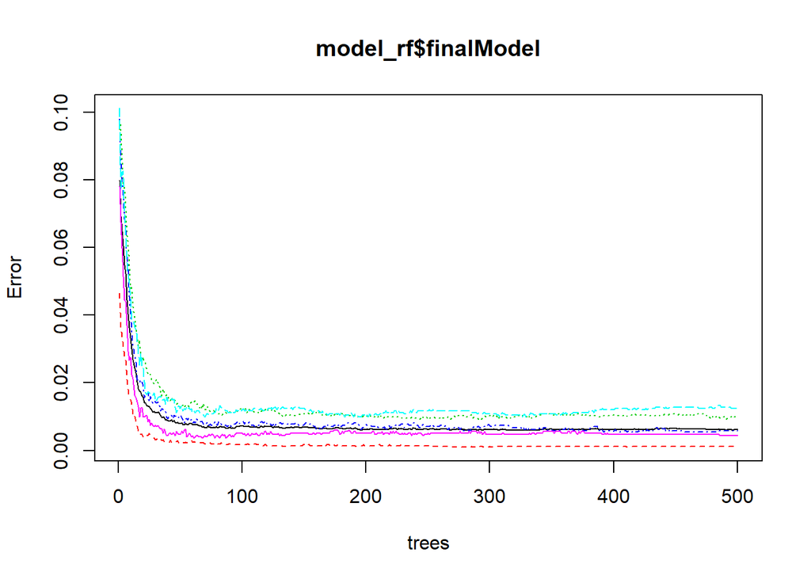

```r
plot(model_rf$finalModel)
```

## Predicting Test Outcome

Now we will use our final model to predict outcome for our test data set.

```r
final_prediction <- predict(model_rf, newdata = test)
final_prediction
```

```
##  [1] B A B A A E D B A A B C B A E E A B B B
## Levels: A B C D E
```

## Conclusion

```r
final_prediction
```

```
##  [1] B A B A A E D B A A B C B A E E A B B B
## Levels: A B C D E
```